# My Simple Linear Regression

## My Simple Linear Regression Analysis

### Background

This analysis investigates tennis serve speed based on serve order using the TennisServes.csv dataset. The goal is to determine if serve speed decreases as the serve order increases.

*Response Variable:* ServeSpeed_mph (Serve Speed in mph).

*Explanatory Variable:* ServeOrder (Order of the serve).

### Hypotheses

**Null Hypothesis (𝐻0 ):** Serve speed is not related to serve order (𝛽1=0)

**Alternative Hypothesis (𝐻𝑎 ):** Serve speed decreases with serve order (𝛽1<0).

**Model**

ServeSpeed_mph=β 0+β 1 *ServeOrder + ϵ

### Correlation and Scatterplot

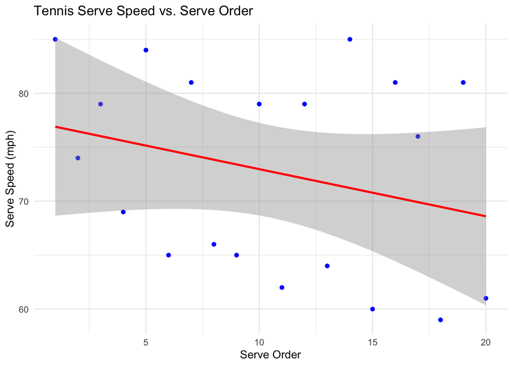

```r
correlation <- cor(tennis_serves$ServeOrder, tennis_serves$ServeSpeed_mph)

ggplot(data = tennis_serves, aes(x = ServeOrder, y = ServeSpeed_mph)) +
  geom_point(color = "blue") +
  geom_smooth(method = "lm", se = TRUE, color = "red") +
  labs(
    title = "Tennis Serve Speed vs. Serve Order",
    x = "Serve Order",
    y = "Serve Speed (mph)"
  ) +
  theme_minimal()
```

```r
correlation
```

```
## [1] -0.2797328
```

The correlation coefficient measures the strength and direction of the linear relationship between serve order and serve speed.

###Linear Regression Model

```r
model <- lm(ServeSpeed_mph ~ ServeOrder, data = tennis_serves)


summary(model)
```

```
##
## Call:
## lm(formula = ServeSpeed_mph ~ ServeOrder, data = tennis_serves)
##
## Residuals:
##      Min       1Q   Median       3Q      Max
## -10.7842  -7.9829   0.2553   7.2039  13.7789
##
## Coefficients:
##             Estimate Std. Error t value Pr(>|t|)
## (Intercept)  77.3368     4.2333  18.269 4.57e-13 ***
## ServeOrder   -0.4368     0.3534  -1.236    0.232
## ---
## Signif. codes:  0 '***' 0.001 '**' 0.01 '*' 0.05 '.' 0.1 ' ' 1
##
## Residual standard error: 9.113 on 18 degrees of freedom
## Multiple R-squared:  0.07825,    Adjusted R-squared:  0.02704
## F-statistic: 1.528 on 1 and 18 DF,  p-value: 0.2323
```

*Y-Intercept (𝛽0β0):* The y-intercept is 77.34 mph. This means that when the serve order is 0 (which might be theoretical, as serve orders generally start at 1), the predicted serve speed is approximately 77.34 mph. **Highly Significant**

*Slope (𝛽1β1):* The slope is -0.44 mph per serve. This indicates that for every additional serve in the sequence, the serve speed decreases by 0.44 mph. However, this relationship is **not statistically significant** (p-value = 0.232).

Residual Standard Error (RSE): This represents the average distance of observed serve speeds from the predicted serve speeds. The model’s predictions are, on average, off by about 9.11 mph.

**R^2=0.078:**This means that only 7.8% of the variation in serve speed can be explained by serve order. The adjusted 𝑅^2=0.027 accounts for the number of predictors and sample size, showing an even weaker fit.

**F-Statistic:** 1.528,p=0.2323: This indicates that the model, as a whole, does not significantly explain the variation in serve speed.

The lack of statistical significance for the slope (p=0.232) and the low 𝑅^2 suggest that serve order is **not** a strong predictor of serve speed.

### Check Assumptions

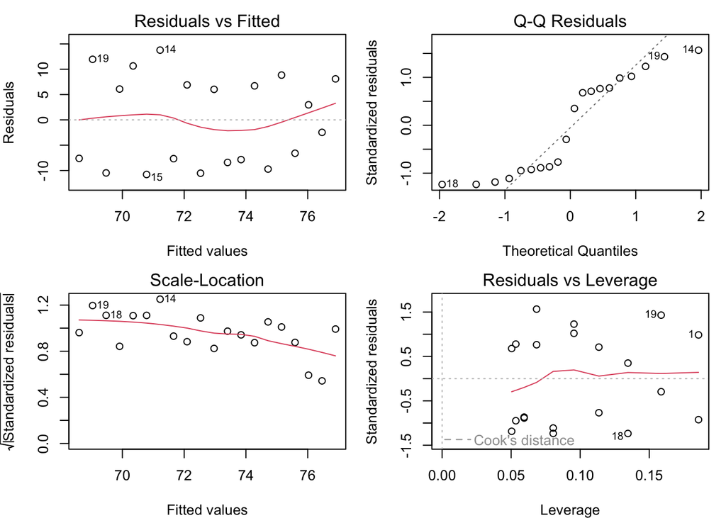

```r
par(mfrow = c(2, 2), mar = c(4, 4, 2, 1))  # Adjust margins
plot(model)
```

*Linearity:* The relationship between serve order and serve speed appears to be linear based on the model. Scatterplots should be reviewed to confirm this assumption. *Independence:* Each serve is assumed to be independent. If there’s a pattern of grouping (e.g., serves from the same player), this might violate independence. *Homoscedasticity:* Residuals should have constant variance. A residual plot can be examined to ensure no pattern exists (e.g., funnel shape). *Normality of Residuals:* The residuals should follow a normal distribution. A histogram or Q-Q plot of residuals can be used to check this assumption.

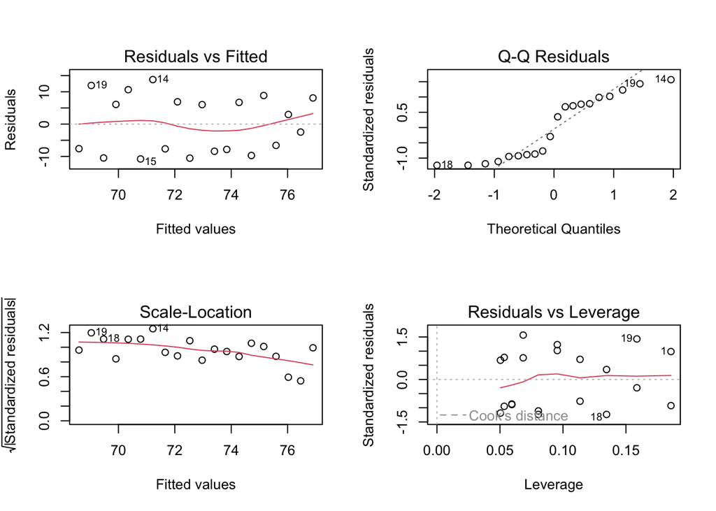

```r
par(mfrow= c(2,2))
plot(model)
```

### Conclusions and Future Studies

The regression model indicates a negative relationship between serve order and serve speed, but this relationship is not statistically significant.It is more likely that other factors play a role in determining serve speed.

For a future study, I would recommened including other factors/variables such as player fatique, serve type, weather, and player skill level.